# Mesure et évolution de la volatilité d'un indice financier : cas du S&P 500

**Auteur : HAYANA Sébastien**  
**Formation : Master 2 en Probabilités, Statistique et Finance**  
**Établissement : Université de Yaoundé 1**  
**Cameroun, 2026**

# Analyse de la volatilité d'un indice financier

## Introduction

Ce projet porte sur l'évolution de la volatilité d'un indice financier à partir de ses prix historiques.

L'objectif est de calculer les rendements journaliers, de mesurer la volatilité sur différentes fenêtres et d'identifier les périodes calmes et agitées.

## Lien avec le second projet

Dans ce projet, j'étudie l'évolution de la volatilité du S&P 500 au cours du temps. J'utilise une volatilité glissante sur 20 jours, puis une comparaison avec une fenêtre de 60 jours, ce qui me permettra d'observer les périodes où le marché est relativement plus calme ou plus agité.

Les deux projets sont complémentaires, mais ils ne répondent pas exactement à la même question. Le projet 1 montre que la volatilité peut évoluer selon les périodes, tandis que le projet 2 étudie le cas simplifié d'une volatilité fixe dans le cadre de cette étude.

## Démarche de projet

J'ai réalisé ce projet progressivement. J'ai d'abord téléchargé les données du S&P 500, puis j'ai examiné leur structure avant de calculer les rendements journaliers et la volatilité glissante. J'ai ensuite comparé les fenêtres de 20 et 60 séances afin d'identifier les périodes plus calmes ou plus agitées.

Pour cette analyse, j'ai utilisé Python et les bibliothèques pandas, NumPy, Matplotlib et yfinance. Chaque étape a été vérifiée dans le notebook afin de mieux comprendre les calculs et d'interpréter les résultats obtenus.

```python
# !pip install yfinance
```

```python
%pip install --upgrade --no-cache-dir yfinance
```

```python
import yfinance as yf
print ("C'est bien là!")
```

```
C'est bien là!
```

```python
# import des librairies
import pandas as pd
import numpy as np
import matplotlib.pyplot as plt
import yfinance as yf
```

```python
# choix de actif et téléchargement des données
ticker = "^GSPC"  # S§P 500
data = yf.download(ticker,period= "2y", interval= "1d")
```

```
[*********************100%***********************]  1 of 1 completed
```

## Exploration des données

Nous commençons par observer la structure du tableau téléchargé.

```python
print(data.head())
```

```
Price             Close         High          Low         Open      Volume
Ticker            ^GSPC        ^GSPC        ^GSPC        ^GSPC       ^GSPC
Date
2024-09-30  5762.479980  5765.140137  5703.529785  5726.520020  4425730000
2024-10-01  5708.750000  5757.729980  5681.279785  5757.729980  4025180000
2024-10-02  5709.540039  5719.629883  5674.000000  5698.140137  3829050000
2024-10-03  5699.939941  5718.779785  5677.370117  5698.189941  3597450000
2024-10-04  5751.069824  5753.209961  5702.830078  5737.479980  3479400000
```

```python
print(data.head(10))
```

```
Price             Close         High          Low         Open      Volume
Ticker            ^GSPC        ^GSPC        ^GSPC        ^GSPC       ^GSPC
Date
2024-09-30  5762.479980  5765.140137  5703.529785  5726.520020  4425730000
2024-10-01  5708.750000  5757.729980  5681.279785  5757.729980  4025180000
2024-10-02  5709.540039  5719.629883  5674.000000  5698.140137  3829050000
2024-10-03  5699.939941  5718.779785  5677.370117  5698.189941  3597450000
2024-10-04  5751.069824  5753.209961  5702.830078  5737.479980  3479400000
2024-10-07  5695.939941  5739.339844  5686.850098  5737.799805  3637790000
2024-10-08  5751.129883  5757.600098  5714.560059  5719.140137  3393400000
2024-10-09  5792.040039  5796.799805  5745.020020  5751.799805  3650340000
2024-10-10  5780.049805  5795.029785  5764.759766  5778.359863  3208790000
2024-10-11  5815.029785  5822.129883  5775.089844  5775.089844  3208720000
```

```python
print( "nombre de lignes:",len(data))
```

```
nombre de lignes: 502
```

```python
print(data.shape)
print (data.columns)
print(data.index)
```

```
(502, 5)
MultiIndex([( 'Close', '^GSPC'),
            (  'High', '^GSPC'),
            (   'Low', '^GSPC'),
            (  'Open', '^GSPC'),
            ('Volume', '^GSPC')],
           names=['Price', 'Ticker'])
DatetimeIndex(['2024-09-30', '2024-10-01', '2024-10-02', '2024-10-03',
               '2024-10-04', '2024-10-07', '2024-10-08', '2024-10-09',
               '2024-10-10', '2024-10-11',
               ...
               '2026-09-17', '2026-09-18', '2026-09-21', '2026-09-22',
               '2026-09-23', '2026-09-24', '2026-09-25', '2026-09-28',
               '2026-09-29', '2026-09-30'],
              dtype='datetime64[ns]', name='Date', length=502, freq=None)
```

```python
print(data.info())
```

```
<class 'pandas.core.frame.DataFrame'>
DatetimeIndex: 502 entries, 2024-09-30 to 2026-09-30
Data columns (total 5 columns):
 #   Column           Non-Null Count  Dtype
---  ------           --------------  -----
 0   (Close, ^GSPC)   502 non-null    float64
 1   (High, ^GSPC)    502 non-null    float64
 2   (Low, ^GSPC)     502 non-null    float64
 3   (Open, ^GSPC)    502 non-null    float64
 4   (Volume, ^GSPC)  502 non-null    int64
dtypes: float64(4), int64(1)
memory usage: 23.5 KB
None
```

```python
close = data["Close"]
print(close.head())
```

```
Ticker            ^GSPC
Date
2024-09-30  5762.479980
2024-10-01  5708.750000
2024-10-02  5709.540039
2024-10-03  5699.939941
2024-10-04  5751.069824
```

## Évolution du prix de clôture

Le garphique suivant permet d'anayser la tendance générale du prix au cours de la période étudiée.

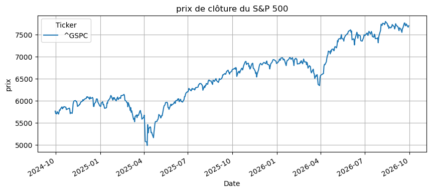

```python
import matplotlib.pyplot as plt

close.plot(figsize=(10,4),title= "prix de clôture du S&P 500")
plt.xlabel("Date")
plt.ylabel("prix")
plt.grid(True)
plt.show()
```

Le prix évolue de manière variable au cours de la période donnée. Les fluctuations visibles ne mesurent pas directement la volatilité comme on pourrait le penser au début ; C'est pourquoi je calcule ensuite les rendements et leur écart type.

## Méthodologie

Les prix de clôture ont été utilisés pour calculer les rendements journaliers . En effet , je m'intéresse aux paramètres qui résument la journée boursière.

Le rendement simple est calculé avec la formule ci-dessus qui mesure la variation relative entre deux prix successifs:

$R_t = \frac{P_t - P_t-1}{ P_t-1}$

La volatilité sur 20 jours correspond à l'écart type des rendements observées sur une fenêtre mobile de 20 jours. La volatilité est ensuite annualisée en la multipliant par la racine carrée de 252 qui correspond approximativement aux séances de marché durant une année ou aux jours de cotation boursière dans une année.

### Remarque sur le rendement logarithmique

Une autre mesure courante est le rendement logarithmique, défini par : $$ r_t^{log} = \ln\left(\frac{P_t}{P_{t-1}}\right) $$

Il est également appelé rendement à capitalisation continue. Contrairement au rendement simple, les rendements logarithmiques peuvent être additionnés sur plusieurs périodes pour obtenir le rendement logarithmique cumulé.

Dans ce projet, le rendement simple a été retenu car il est plus intuitif et permet d'interpréter directement les variations quotidiennes en pourcentage. Le rendement logarithmique aurait toutefois été adapté à une analyse statistique ou à une modélisation plus avancée.

## Calcul des rendements

Nous calculons les variations journalières du prix de clôture afin de mesurer les mouvements quotidiens de l'indice.

```python
# CALCUL DES RENDEMENTS SIMPLES
returns = close.pct_change()    # la methode pct_change compare chaque valeur avec la valeur précédente
print(returns.head())
```

```
Ticker         ^GSPC
Date
2024-09-30       NaN
2024-10-01 -0.009324
2024-10-02  0.000138
2024-10-03 -0.001681
2024-10-04  0.008970
```

```python
data["return"]= data["Close"].pct_change() # la methode pct_change compare chaque valeur avec la valeur precédente
# Là,la colonne des rendemnts journaliers a été crée .
```

```python
print(data[["Close","return"]].head())
```

```
Price             Close    return
Ticker            ^GSPC
Date
2024-09-30  5762.479980       NaN
2024-10-01  5708.750000 -0.009324
2024-10-02  5709.540039  0.000138
2024-10-03  5699.939941 -0.001681
2024-10-04  5751.069824  0.008970
```

La première valeur est **NaN** ,car aucun rendement ne peut être calculé pour la première date : il n'existe en fait pas encore de prix précédent.

## Évolution des rendements journaliers

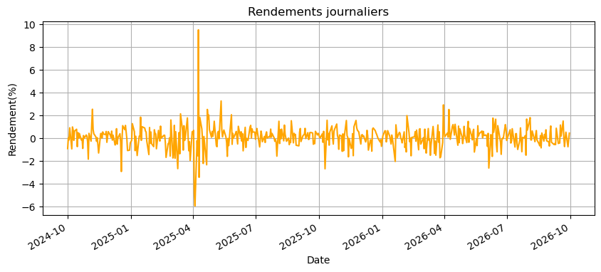

```python
# tracé des rendements

(data["return"]*100).plot(figsize=(10,4),title= "Rendements journaliers",color= "orange")
plt.xlabel("Date")
plt.ylabel("Rendement(%)")
plt.grid(True)
plt.show()
```

### Interprétation des rendements journaliers

Le graphique montre les variations quotidiennes du prix sous forme de rendements.

Les valeurs positives correspondent aux journées où le prix a augmenté, tandis que les valeurs négatives correspondent aux journées où le prix a diminué. Les rendements sont généralement proches de zéro, mais certaines dates présentent encore des mouvements plus importants.

Les pics positifs et négatifs indiquent des journées où le marché a connu des variations plus fortes que d'habitude. Ce graphique permet peut-être d'identifier des mouvements journaliers importants, mais il ne mesure pas directement la volatilité sur une période complète.

```python
print( data.shape)
print(data.columns)    # Petite vérification pour l'ajout de la colonne des rendements
print(data[["Close","return"]].head())
```

```
(502, 6)
MultiIndex([( 'Close', '^GSPC'),
            (  'High', '^GSPC'),
            (   'Low', '^GSPC'),
            (  'Open', '^GSPC'),
            ('Volume', '^GSPC'),
            ('return',      '')],
           names=['Price', 'Ticker'])
Price             Close    return
Ticker            ^GSPC
Date
2024-09-30  5762.479980       NaN
2024-10-01  5708.750000 -0.009324
2024-10-02  5709.540039  0.000138
2024-10-03  5699.939941 -0.001681
2024-10-04  5751.069824  0.008970
```

## Volatilité glissante sur 20 jours et graphique

Nous calcule la volatilité sur une fenêtre glissante de 20 jours. Pour chaque date ,l'écart type est calculé à partir des rendements des 20 dernières séances.

Nous présentons ensuite cette volatilité sous deux formes:

*La volatilité non annualisée, qui reste exprimée sur l'échelle des rendements journaliers.

*La volatilité annualisée qui convertit notre mesure journalière en une estimation sur une base annuelle

La volatilité annualisée est obtenue en multipliant la volatilité non annualisée par la racine carrée de 252, qui correspond approximativement au nombre de séances boursières dans une année.

```python
data["volatility_20d"] = data["return"].rolling(window=20).std()
```

```python
data.columns= data.columns.get_level_values(0)      # afin de faciliter la lecture de mon Dataframe et eviter les erreurs pour la mauvaise gestion du multiIndex
```

```python
print(data[["return","volatility_20d"]].head(25)) # Afin de remarquer logiquement les valeurs Nan
```

```
Price         return  volatility_20d
Date
2024-09-30       NaN             NaN
2024-10-01 -0.009324             NaN
2024-10-02  0.000138             NaN
2024-10-03 -0.001681             NaN
2024-10-04  0.008970             NaN
2024-10-07 -0.009586             NaN
2024-10-08  0.009689             NaN
2024-10-09  0.007113             NaN
2024-10-10 -0.002070             NaN
2024-10-11  0.006052             NaN
2024-10-14  0.007708             NaN
2024-10-15 -0.007609             NaN
2024-10-16  0.004679             NaN
2024-10-17 -0.000171             NaN
2024-10-18  0.003972             NaN
2024-10-21 -0.001823             NaN
2024-10-22 -0.000475             NaN
2024-10-23 -0.009191             NaN
2024-10-24  0.002146             NaN
2024-10-25 -0.000299             NaN
2024-10-28  0.002651        0.006054
2024-10-29  0.001614        0.005592
2024-10-30 -0.003300        0.005675
2024-10-31 -0.018615        0.007154
2024-11-01  0.004093        0.006914
```

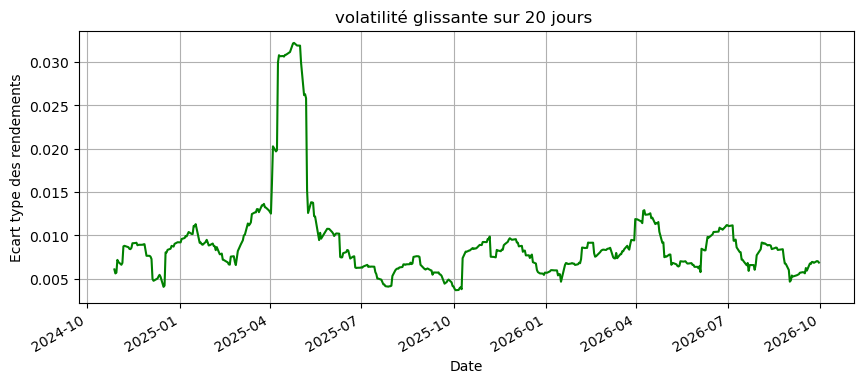

```python
data["volatility_20d"].plot( figsize= (10,4), title= "volatilité glissante sur 20 jours ", color= "green")
plt.xlabel("Date")
plt.ylabel("Ecart type des rendements")
plt.grid(True)
plt.show()
```

### Interprétation

La courbe représente la variation de la dispersion des rendements au fil du temps.

Lorsque la courbe augmente, les rendements des 20 dernières séances sont davantage dispersés. Le marché a alors connu des mouvements plus irréguliers ou plus importants.

Lorsque la courbe diminue, les rendements récents sont plus proches les uns des autres et la période est relativement plus calme.

Cette mesure est utile pour observer l'évolution de la volatilité dans le temps. Toutefois, comme elle n'est pas annualisée, ses valeurs sont moins faciles à comparer avec des indicateurs financiers généralement exprimés en pourcentage annuel. Ainsi,cette volatilité sera exprimée en pourcentage annuel dans la suite.

```python
print(data[["return","volatility_20d"]].tail()) # Curieux de savoir à quoi ressemble les dernières valeurs
print(data["volatility_20d"].dropna().iloc[-1]) # iloc affiche la dernière valeur valeur disponible de la colonne
```

```
Price         return  volatility_20d
Date
2026-09-24 -0.000247        0.006911
2026-09-25  0.005099        0.006814
2026-09-28 -0.007712        0.007016
2026-09-29 -0.001672        0.006986
2026-09-30  0.004267        0.006845
0.006845255082106596
```

### Volatilité annualisée et graphique

Je convertis maintenant la volatilité non annualisée en volatilité annualisée .Ce redimensionnement nous permettra d'avoir une volatilité sur une base annuelle et exprimée en pourcentage.

```python
data["volatility_20d_annualized"]= ( data["volatility_20d"] * (252 ** 0.5))
```

```python
data["volatility_20d_annualized_pct"]= (data["volatility_20d_annualized"] * 100) # volatilité annualisée en pourcentage
```

```python
print( data[["return","volatility_20d","volatility_20d_annualized_pct"]].tail()) # Afin de voir les nouvelles colones ajoutées et curieusement les derniéres valeurs.
```

```
Price         return  volatility_20d  volatility_20d_annualized_pct
Date
2026-09-24 -0.000247        0.006911                      10.971050
2026-09-25  0.005099        0.006814                      10.817412
2026-09-28 -0.007712        0.007016                      11.137570
2026-09-29 -0.001672        0.006986                      11.090724
2026-09-30  0.004267        0.006845                      10.866506
```

Ce graphique ci dessous reprend la même volatilité calculée sur une fenêtre de 20 séances , mais annualisée et exprimée en pourcentage.

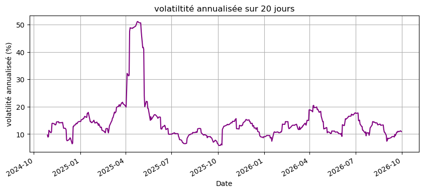

```python
data["volatility_20d_annualized_pct"].plot( figsize=(10,4),title= "volatiltité annualisée sur 20 jours",color= "purple")
plt.xlabel("Date")
plt.ylabel("volatilité annualiseé (%)")
plt.grid(True)
plt.show()
```

### Interprétation

La volatilité annualisée présente une forme générale assez similaire à celle de de la volatilité non annualisée. Cela est naturel car les deux volatilités utilisent les mêmes rendements.

La différence réside uniquement au niveau de l'échelle où la volatilité annualisée est calculé en pourcentage annuel afin de faciliter son inteprétation et sa comparaison avec les indicateurs financiers.

### Synthèse

#### Comparaison des deux mesures

La volatilité non annualisée et la volatilité annualisée sont calculées sur la même fenêtre glissante de 20 séances. La première conserve l'échelle issue des rendements journaliers, tandis que la seconde est convertie sur une base annuelle et exprimée en pourcentage.

L'annualisation ne modifie pas la dynamique de la courbe. Elle modifie seulement l'unité et l'échelle des valeurs. Les deux graphiques présentent donc généralement une forme similaire, mais la volatilité annualisée est plus facile à interpréter dans un contexte financier.

### Comparaison avec la volatilité moyenne

Je compare la volatilité annualisée sur une fénêtre de 20 jours à sa moyenne calculée sur toute la période étudiée. La moyenne sert de seuil de référence. Elle permet de distinguer les périodes où la volatilité est supérieure à son niveau habituel dans l'échantillon, et les périodes où elle inférieure.

#### Illustration

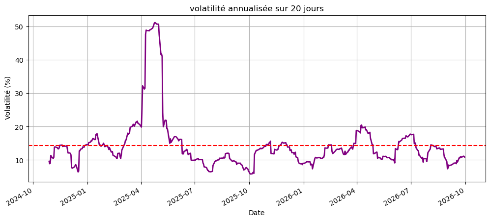

```python
vol = data["volatility_20d_annualized_pct"].dropna()
moyenne= vol.mean()
vol.plot(figsize= (12,5), color= "purple", linewidth= 2)
plt.axhline(moyenne,color= "red",linestyle="--")
plt.title("volatilité annualisée sur 20 jours")
plt.xlabel("Date")
plt.ylabel(" Volatilité (%)")
plt.grid(True)
plt.show()
```

### Interprétation

La ligne rouge représente la volatilité moyenne calculée sur l'ensemble de la période étudiée.

La courbe violette représente la volatilité calculée sur les 20 dernières séances à chaque date.

Lorsque la courbe violette se situe au dessus de la ligne rouge, la volatilité sur les 20 dernières séances est supérieure à la moyenne de l'échantillon . Cela correspond à une période relativement plus agitée du marché.

Par contre,lorsque la courbe se situe en dessous de la ligne rouge , la volatilité sur les 20 dernières séances est inférieure à la moyenne.Cela correspond à une période relativement plus calme.

Notons que la dernière valeur de la courbe correspond à la volatilité calculée sur les 20 dernières séances disponibles et non le rendement du dernier jour uniquement.

### Résumé statistique de la volatilité

Après avoir observé l'évolution de la volatilité sur le graphique , Je calcule à présent quatre indicateurs qui permettront de mesurer le degré de volatilité obsevée durant notre période étudiée: volatilité minimale,volatilité maximale,volatilité moyenne,volatilité récente.

```python
 vol = data["volatility_20d_annualized_pct"].dropna() # On retire les valeurs manquantes
print("volatilité minimale:",round(vol.min(),2),"%")
print("volatilité maximale:",round(vol.max(),2),"%")
print("volatilité récente:",round(vol.iloc[-1],2),"%")
print("Volatilité moyenne:",round(vol.mean(),2),"%")
```

```
volatilité minimale: 5.81 %
volatilité maximale: 51.12 %
volatilité récente: 10.87 %
Volatilité moyenne: 14.32 %
```

### Interprétation et synthèse

La volatilité minimale correspond à la période la plus faible observé pendant notre période étudiée.Elle correpond à une période où les rendements des 20 dernières séances etaient relativement très peu dispersés

La volatilité maximale correspond à la période la forte observée pendant notre pérode étudiée. Elle correspond à une période où les rendements des 20 jours étaient les plus dispersés pour notre période et où les mouvements de marché étaient importants .

La volatilité moyenne sert ici de seuil de référence pour l'ensemble de la période.

La volatilité récente ou encore la dernière valeur disponible de la volatilité résume les 20 dernières valeurs de rendements à la fin de l'échantillon. Ce qui est intéressant, c'est qu'elle peut étre comparée à la moyenne pour déterminer si la période finale est relativement calme ou agitée : Dans notre cas , on voit très bien que la période est calme car la volatilité moyenne est de 14,32 % et la volatilité récente est de 10,87 % .

```python
# Les valeurs précédentes montre que la période actuelle du marché est plus calme que la moyenne
# si la récente était supérieure à la moyenne alors la periode actuelle serait plus agitée que la moyenne
#Si elles sont proches , l'utilisation actuelle est relativement normale
ecart= vol.iloc[-1] - vol.mean()
print(" écart par  rapport à la moyenne:", round(ecart,2),"points de pourcentage")
```

```
 écart par  rapport à la moyenne: -3.46 points de pourcentage
```

## Comparaison avec la volatilité sur 60 jours et graphique

Je vais maintenant effectuer une comparaison, disons stratégique, de la volatilité sur différentes fenêtres notamment les fenêtres glissantes sur 20 jours et sur 60 jours.

Nous verrons que la volatilité glissante sur 20 jours réagit plus rapidement aux changements récents, autrement dit,le changement sera bien plus visible .Par contre, étant donné que la fénêtre de 60 jours utilise davantage d'observations, on aura généralement un aspect plus progressif de la volatiltité et sera relativement moins visible.

Les deux mesures sont annualisées et exprimées en pourcentage afin d'être sur le même d'échelle et d'être comparables.

```python
# Nous allons maintenant créer une variante  sur 60 jours et faire une comparaison

data["volatility_60d"]= (data["return"].rolling(window=60).std())
data["volatility_60d_annualized_pct"]= data["volatility_60d"]*(252**0.5)*100
print(data[["volatility_20d_annualized_pct","volatility_60d_annualized_pct"]].tail()) # Illustration curieuse
```

```
Price       volatility_20d_annualized_pct  volatility_60d_annualized_pct
Date
2026-09-24                      10.971050                      11.149026
2026-09-25                      10.817412                      11.175107
2026-09-28                      11.137570                      11.303657
2026-09-29                      11.090724                      11.222757
2026-09-30                      10.866506                      11.206686
```

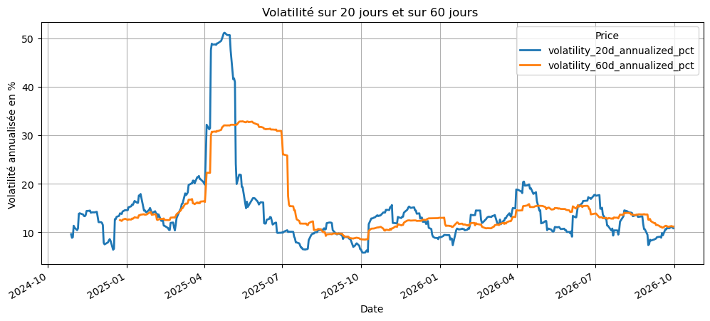

```python
data[["volatility_20d_annualized_pct","volatility_60d_annualized_pct"]].plot(figsize= (12,5),title="Volatilité sur 20 jours et sur 60 jours ", linewidth=2)
plt.xlabel( "Date")
plt.ylabel("Volatilité annualisée en % ")
plt.grid( True)
plt.show()
```

#### Remarque

La fénêtre de 60 jours a besoin de 60 rendements avant de calculer sa première valeur. Les premières lignes peuvent donc contenir la valeur NaN. C'est la raison pour laquelle les deux courbes démarrent tardivement et la courbe de la volatilité sur 60 jours démarre plus tardiment que la courbe de la volatilité sur 20 jours.

### Interprétation

La volatilité sur 20 jours réagit plus rapidement aux changements récents que la volatilité sur 60 jours. C'est même d'ailleurs la raison pour laquelle elle présente des pics plus visibles. La volatilité sur 60 jours par contre réagit de façon plus progressive aux changements car elle prend en compte un grand nombre d'observations, c'est pourquoi on observe une courbe plus lisse.

Lorsque la volatilité sur 20 jours est au dessus de la volatilité sur 60 jours , cela signifie que la volatilité récente ou encore les mouvements récents sont plus importants que la tendance sur une longue période. En revanche, si la courbe passe en dessous de la courbe , cela signifie que les mouvements récents sont devenus relativement plus calmes que ceux observés sur les 60 dernières séances

Certes, nos deux courbes mesurent la volatilité annualisée, mais elles ne répondent pas à la même question : Les 20 jours décrivent le court terme tandis que les 60 jours décrivent une période plus progressive.

## Corrélation et examen de la relation entre les rendements et la volatilité

### Relation entre les rendements et la volatilité

J'étudie la relation entre les rendements journaliers et la volatilité annualisée sur 20 jours.

Deux analyses sont réalisées avec le même nuage de points. Dans la première, je conserve le signe du rendement afin d'étudier le lien avec la direction du mouvement. Dans la seconde, j'utilise la valeur absolue du rendement afin d'étudier le lien avec l'amplitude du mouvement, qu'il soit positif ou négatif.

La volatilité utilisée sur l'axe vertical est la volatilité annualisée sur 20 jours.

```python
# Analyse avec le rendement signé
analyse_signe = data[[ "return","volatility_20d_annualized_pct" ]].dropna()

correlation_signe = analyse_signe["return"].corr(analyse_signe["volatility_20d_annualized_pct"])

# Analyse avec l'amplitude absolue du rendement
data["abs_return"] = data["return"].abs()

analyse_abs = data[[ "abs_return","volatility_20d_annualized_pct"]].dropna()

correlation_abs = analyse_abs["abs_return"].corr(analyse_abs["volatility_20d_annualized_pct"])

print("Corrélation avec le rendement signé :",round(correlation_signe, 3))

print("Corrélation avec l'amplitude absolue :", round(correlation_abs, 3))
```

```
Corrélation avec le rendement signé : 0.081
Corrélation avec l'amplitude absolue : 0.354
```

Illustration

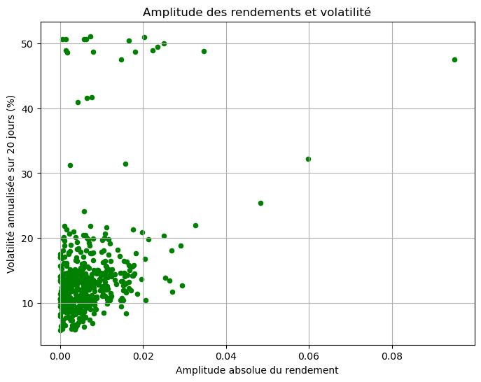

```python
analyse_abs.plot(
    x="abs_return",

   y="volatility_20d_annualized_pct",

    kind="scatter",

    figsize=(8, 6),

    color= "green",

    title="Amplitude des rendements et volatilité"
  )

plt.xlabel("Amplitude absolue du rendement")
plt.ylabel("Volatilité annualisée sur 20 jours (%)")
plt.grid(True)
plt.show()
```

## Interprétation du nuage de points

Le nuage de points est assez dispersé et ne présente pas de tendance linéaire très nette.

La corrélation entre le rendement signé et la volatilité est de 0,081. Cette valeur, très proche de zéro, indique que la direction du rendement journalier explique très peu le niveau de volatilité récente.

Lorsque le rendement est remplacé par sa valeur absolue, la corrélation augmente à 0,354. Cette relation positive, faible à modérée, suggère que les mouvements journaliers de grande amplitude sont plus souvent associés à une volatilité élevée.

La différence entre les deux corrélations montre que la volatilité dépend davantage de l’importance des mouvements que de leur direction. Autrement dit, la volatilité est liée à l’ampleur des variations, qu’elles soient positives ou négatives. Toutefois, la dispersion du nuage de points indique que cette relation reste imparfaite.

Enfin, l’amplitude d’un seul rendement ne suffit pas à expliquer toute la volatilité calculée sur une fenêtre de 20 jours, car cette dernière dépend de l’ensemble des rendements observés pendant cette période.

## Regime de volatilité

### Classification des régimes de volatilité sur 20 jours

Je classe chaque date selon le niveau de volatilité annualisée sur 20 jours.

Cette classification permet de repérer plus facilement les périodes relativement plus calmes et les périodes relativement plus agitées.

```python
seuil= vol.mean()

data["regime volatilite"] = "faible" #là je crèe une nouvelle colonne où toutes les lignes recoivent  la valeur<<faible>>
# on considère toutes les dates comme des périodes de volatilité faible

data.loc[ data["volatility_20d_annualized_pct"]> seuil,"regime volatilite"] = "elevée" # elle signifie simplement si la volatlité d'une date est supérieure à la moyenne , ecris élevée dans la nouvelle colonne regime volatilite
print(data[["volatility_20d_annualized_pct","regime volatilite"]].tail())
```

```
Price       volatility_20d_annualized_pct regime volatilite
Date
2026-09-24                      10.971050            faible
2026-09-25                      10.817412            faible
2026-09-28                      11.137570            faible
2026-09-29                      11.090724            faible
2026-09-30                      10.866506            faible
```

#### Remarque

Les dernières valeurs affichés sont au régime *faible* car les dernières valeurs sont inférieures au seuil moyen.

```python
print(data["regime volatilite"].value_counts())
```

```
regime volatilite
faible    351
elevée    151
Name: count, dtype: int64
```

#### Remarque

Il faut faire attention au calcul du nombre d'occurrences du régime **faible**. En effet les valeurs manquantes ou indisponibles de notre serie de la volatilité annualisée sur 20 jours ont été consideré par défaut inférieur au seuil et prennent automatiquement la chaine de caractère "faible". On règle ce problème avec la solution ci-dessous :

```python
import pandas as pd

def classer_regime(x):
    if pd.isna(x):
        return "indisponible"
    elif x > seuil:
        return "élevée"
    else:
        return "faible"

data["regime_volatilite"] = data["volatility_20d_annualized_pct"].apply(classer_regime)
```

```python
print(data["regime_volatilite"].value_counts())  # Ceci permettra de regler le cas des valeurs NAN CAR par défaut sans ça "NAN> SEUIL" IMPLIQUE la valeur 'faible'
```

```
regime_volatilite
faible          331
élevée          151
indisponible     20
Name: count, dtype: int64
```

#### Remarque

On constate maintenant que le nombre d'occurences du régime **faible** a diminué. Ceci confirme bien évidemment notre hypothèse passée.

### Maximum et minimum

Je recherche maintenant les dates auxquelles la volatilité annualisée sur 20 jours a atteint sa valeur maximale ou sa valeur minimale.

```python
date_max = data["volatility_20d_annualized_pct"].idxmax()
valeur_max = data["volatility_20d_annualized_pct"].max()
print("Date du maximum:",date_max)
print("volatilité maximale:",round(valeur_max,2),"%")
```

```
Date du maximum: 2025-04-25 00:00:00
volatilité maximale: 51.12 %
```

```python
print(data.loc[date_max])# selectionne toute la ligne à partir de l'étiquette relié à date_max
  # Curieux de voir tous les infos précises de cette date...
```

```
Price
Close                            5525.209961
High                             5528.109863
Low                              5455.859863
Open                              5489.72998
Volume                            4236580000
return                              0.007373
volatility_20d                      0.032201
volatility_20d_annualized           0.511177
volatility_20d_annualized_pct      51.117717
volatility_60d                      0.020189
volatility_60d_annualized_pct      32.049483
abs_return                          0.007373
regime volatilite                     elevée
regime_volatilite                     élevée
Name: 2025-04-25 00:00:00, dtype: object
```

```python
date_min = vol.idxmin()
valeur_min = vol.min()

print("Date du minimum:",date_min)
print("volatilité minimale:",round(valeur_min,2),"%")
```

```
Date du minimum: 2025-10-03 00:00:00
volatilité minimale: 5.81 %
```

#### Interprétation

La volatilité annualisée maximale est de 51,12 % le 25 avril 2025. Cette date correspond à la période la plus agitée de notre échantillon.

La volatilité minimale observée est de 5,81 % le 3 octobre 2025. Cette date correspond à la période la plus calme de l'échantillon.

Ces valeurs ne correspondent en aucun cas une perte ou un gain du marché mais plutot des mesures de l'intensité fluctuations des rendements sur une fénêtre glissante de 20 jours exprimées en base annuelle.

```python
# La question suivante qu'on se pose:  EST CE QUE LES RENDEMENTS MOYENS SONT DIFFERENTS PENDANT LES PÉRIODES DE VARIATION FAIBLE ET ÉLEVÉES?

moyennes_regimes=data.groupby( "regime_volatilite")["return"].mean()  # Là on essaie de calculer les moyennes pour chacun des groupes notamment les groupes faibles, élevée, et indisponible qui ne nous servira évidemment pas...
print("Rendements moyens par regime(%):")
print(moyennes_regimes*100)
```

```
Rendements moyens par regime(%):
regime_volatilite
faible          0.034481
indisponible    0.043351
élevée          0.128245
Name: return, dtype: float64
```

#### Interprétation

Le régime faible regroupe ici les dates où la volatilité est inférieur à la moyenne, alors que le régime élevée regroupe ceux dont la volatilité est supérieur à la volatilité moyenne.

### Tableau récapitulatif

Le tableau suivant rassemble les principaux indicateurs calculés pendant l'analyse.

```python
resume = pd.DataFrame({ "indicateur": ["volatilité minimale (%)","volatilité maximale(%)","volatilité récente(%)","volatilité moyenne(%)","Corrélation amplitude-volatilité"],"valeur": [ round(vol.min(),2),round(vol.max(),2),round(vol.iloc[-1],2),round(vol.mean(),2),round(correlation_abs,3)] })
print(resume)
```

```
                         indicateur  valeur
0           volatilité minimale (%)   5.810
1            volatilité maximale(%)  51.120
2             volatilité récente(%)  10.870
3             volatilité moyenne(%)  14.320
4  Corrélation amplitude-volatilité   0.354
```

La volatilité maximale est nettement supérieure à la volatilité minimale, ce qui montre que le niveau d'agitation du marché a fortement variée pendant notre période étudiée.

```python
print(data.columns) # Juste curieux de voir mon tableau de fin
```

```
Index(['Close', 'High', 'Low', 'Open', 'Volume', 'return', 'volatility_20d',
       'volatility_20d_annualized', 'volatility_20d_annualized_pct',
       'volatility_60d', 'volatility_60d_annualized_pct', 'abs_return',
       'regime volatilite', 'regime_volatilite'],
      dtype='object', name='Price')
```

## Résultats principaux

-La volatilité minimale observée est de 5,81%, le 3 octobre 2025.

-La volatilité maximale observée est de 51,12%, le 25 avril 2025.

-La volatilité récente est 10,87%.

-La corrélation entre l’amplitude absolue des rendements et la volatilité est de 0,354.

-La période étudiée contient 331 observations classées dans le régime de volatilité faible et 151 observations classées dans le régime de volatilité élevée.

-Enfin, 20 observations sont indisponibles au début de la série, car la fenêtre de 20 jours n’est pas encore complète.

## Conclusion

Cette étude m'a permis d'analyser la volatilité d'un indice financier à partir de ses prix historiques.

Les rendements journaliers ont été calculés à partir de prix de clôture, puis une volatilité glissante sur 20 jours a été estimée et annualisée. Ensuite une comparaison avec une fenêtre de 60 jours a permis de distinguer les variations rapides des tendances plus générales.

La volatilité maximale observée est de 51,12 % le 25 avril 2025, tandis que la volatilité minimale est de 5,81 % le 3 octobre 2025. La volatlité récente, proche de 11 % , est nettement inférieure au maximun observée.

Enfin , la corrélation de 0,354 entre l'amplitude absolue des rendements et la volatilité indique une relation positive faible à modérée.

Ces résultats décrivent uniquement la période étudiée , mais ne permettent de decrire avec certitude les mouvements futurs du marché.

Après les calculs et les interprétations, nous enregistrons à présent le tableau final dans un fichier **CSV** afin de conserser les données pour les utiliser ultérieurement.Ce fichier contient les prix, les rendements, les volatilités sur 20 et 60 jours , les versions annualisées et la classification de nos régimes de volatilité.

```python
data.to_csv( "analyse volatilite_finale.csv",index=True)
```

```python
import os
print(os.path.exists("analyse volatilite_finale.csv"))
```

```
True
```

## Références

Yahoo Finance, données historiques du S&P 500 (^GSPC), utilisées comme source des prix de clôture : https://finance.yahoo.com/quote/%5EGSPC/history/

yfinance, documentation de la fonction `download()`, utilisée pour télécharger les données avec Python : https://ranaroussi.github.io/yfinance/reference/api/yfinance.download.html

pandas, documentation de `pct_change()`, utilisée pour calculer les rendements journaliers : https://pandas.pydata.org/docs/reference/api/pandas.Series.pct_change.html

pandas, documentation de `rolling()`, utilisée pour calculer la volatilité sur une fenêtre mobile : https://pandas.pydata.org/docs/reference/api/pandas.DataFrame.rolling.html